# National and Seasonal Effects on COVID Deaths

Oscar Rivera

3/1/2022

# Introduction

When the COVID-19 virus made its presence in North America, it was very quick to make a negative impact on the nations in this continent, with those nations being the United States, Canada, and Mexico. Having settled in these nations, the virus brought a significant number of infections and deaths to those living in these nations within first two years of its presence. Throughout these two years, there were certain time periods in which the number of deaths due to COVID rose up drastically. Furthermore, these number of deaths turned out to be much higher for some nations. Since the virus became a threat to the world, The World Health Organization (WHO) has been monitoring the number of deaths and cases per for various countries around the globe. The data set which WHO uses to keep track of these number can observed through the [weekly WHO COVID-19 update](https://www.who.int/emergencies/diseases/novel-coronavirus-2019/situation-reports). For this project, we will focus on determining whether the nations in North America and the seasons of the year have major effects on the number of deaths caused by COVID-19 during the pandemic.

# Background

The data set that we will be working with to answer the following question is WHO COVID-19 data set that was mentioned in the introduction. Through this data set, WHO has managed to keep track of the daily and cumulative number of COVID cases and deaths between January 20202 to present day as well as for all nations across the globe.

Since our question of interest is focused on countries in North America, we minimized the observations to those involving the United States, Canada, and Mexico. Around March 2020, the number of COVID cases and deaths became more recognized in North America in the sense that the nations in this continent began taking serious measures to control for these number. With this being said, I have restricted this data set to dates between March 1, 2020 to February 28, 2022. In addition, applying this restriction on the data set give more flexibility to use appropriate methods in my analysis, which will be discussed later.

# Exploratory Data Analysis

Restricting the WHO data to the United States, Canada, and Mexico and to the dates March 1 2020 - February 28 2022, the modified data set contains 2190 total observations.

## Time Series Plots

To study the daily number of deaths, cases, and case-fatality rates due to COVID within a span of two years, I created a times series plot of these numbers for all three nations.

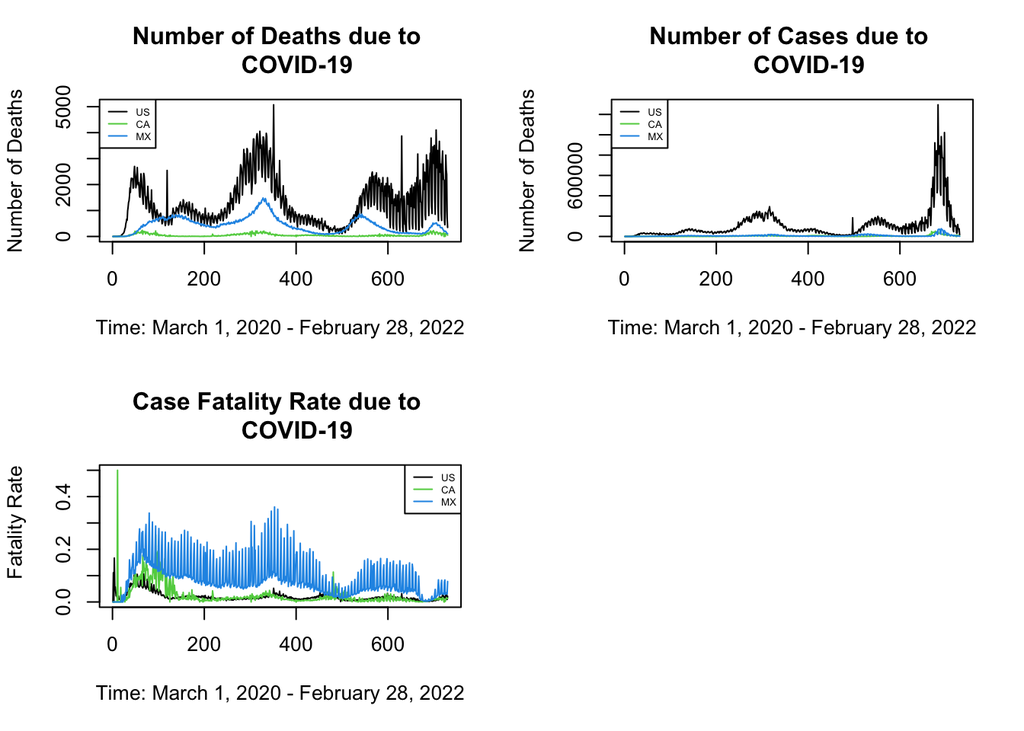

Looking at the time series plot of the COVID deaths for the three nations (topleft), all three countries appear to show similar trends. In all time periods, Canada tends to have the lowest number of deaths despite being the largest country from the three. Although it seems that COVID deaths are higher for the US, one can see that these numbers for all three nations tend to fluctuate roughly around the same time of the year. This may be an indication that the seasons of each year may play a role on the number of deaths rising up so rapidly. In the time series plot of the COVID cases for the three countries (topright), the US tends to have the highest number of cases. Further, it shows that the US had quite some time periods where the cases got significantly high. Near the ending of this plot, one can observe that the cases for all three nation increased around the same time period. In the time series plot of the CFR for the three countries (bottomleft), Mexico appears to have the highest CFR. Note that Canada has a very high CFR value for one of the dates. The reason for the CFR being that high is because on that day, there two COVID cases and one COVID, leading to $CFR=1/2$. The date corresponding to this is March 11, 2020, which is the day Canada reported it’s first COVID death.

## Sample Averages

To study the average numbers number of deaths caused by COVID in it’s two-year present, we provided these average numbers by country and season in the table below.

```
##    Country Season     Deaths       Cases        CFR
## 1       CA   Fall   30.79670   2919.9231 0.01025727
## 2       MX   Fall  392.00000   5594.0330 0.08680082
## 3       US   Fall 1208.68681  91559.6923 0.01400171
## 4       CA Spring   57.38587   3287.9620 0.03605372
## 5       MX Spring  244.07609   2280.7283 0.10560971
## 6       US Spring  960.02717  34661.0054 0.03346650
## 7       CA Summer   19.23913    840.8641 0.03459386
## 8       MX Summer  522.67391   8204.4348 0.08800536
## 9       US Summer  725.83152  54951.7283 0.01766130
## 10      CA Winter   93.43333  11051.9556 0.01344944
## 11      MX Winter  594.31667  14468.2444 0.07712740
## 12      US Winter 2281.91111 250278.1833 0.01392778
```

Viewing this table, one can observe that the average number of deaths and average number of case due to COVID is highest for the US in all seasons. Notice that in spring seasons, the average cases for Canada are higher than that of Mexico; however, the average cases are a lot lower for Canada during the summer time. The highest average case fatality rate goes to Mexico during the spring season. One interesting observation to notice is that the average number of deaths and the average number of cases caused by COVID tend to be highest for all three nation during the winter time.

## Five-Number Summary

The following table displays the five-number summary of COVID Deaths by country and season:

```
## # A tibble: 12 × 7
## # Groups:   Country_code [3]
##    Country_code Season   min     Q1 median     Q3   max
##    <fct>        <fct>  <dbl>  <dbl>  <dbl>  <dbl> <dbl>
##  1 CA           Fall       0   11     25     45     102
##  2 CA           Spring     0   26     41     73.5   235
##  3 CA           Summer     0    6     11     23.5   213
##  4 CA           Winter     0   42.5   94.5  136     226
##  5 MX           Fall     110  267    410.   500     757
##  6 MX           Spring     0   90.5  214.   396.    628
##  7 MX           Summer    69  224    636.   734     870
##  8 MX           Winter    90  162.   544.   900.   1483
##  9 US           Fall     172  727   1070.  1660    3871
## 10 US           Spring     0  510.   803   1402.   2699
## 11 US           Summer   106  368.   696.   970.   2544
## 12 US           Winter   248 1586.  2312.  3068    5074
```

The table shows that Spring is the only season where the minimum number of COVID deaths for the three countries is 0. This is because most deaths did not occur in these countries the begin of Spring in 2020. Notice that the median number of deaths for Mexico and the US are not too apart from each other. The spring time brought the maximum number of deaths for Canada, whereas the winter time brought the number of maximum number of deaths for the US and Mexico.

The next following table shows the five-number summary of COVID Cases by country and season:

```
## # A tibble: 12 × 7
## # Groups:   Country_code [3]
##    Country_code Season   min      Q1  median      Q3     max
##    <fct>        <fct>  <dbl>   <dbl>   <dbl>   <dbl>   <dbl>
##  1 CA           Fall       0   2062    2673    4058     9005
##  2 CA           Spring     0   1151    2149    5452    10275
##  3 CA           Summer     0    341     538     918.    4004
##  4 CA           Winter     0   4261    6773   11224    56030
##  5 MX           Fall     858   3030    5260.   7248    17739
##  6 MX           Spring     2    770.   2042    3520     8625
##  7 MX           Summer   842   3836    6618.   8786    25339
##  8 MX           Winter   849   3994    9689   17234    76534
##  9 US           Fall   22672  49225   85351  124126   198349
## 10 US           Spring     4  21834.  29478.  52578    77094
## 11 US           Summer  8335  20705   46264.  67382   186309
## 12 US           Winter 16322 110490  187165  251146. 1294746
```

Notice that the minimum number of cases for Canada in all seasons is 0. This indicates that Canada had days in all seasons where no cases were reported. Neither the US nor Mexico had 0 cases in any seasons during this two-year timeline. The median number of cases appears to be highest for the US. The table also shows that the median and maximum number of cases in all three nations were highest during the winter time.

From both tables, it appears that both nations and seasons may have some role in the number of deaths and cases.

## Interaction Plot of Average COVID Deaths by Country and Season

To examine the effects these seasons and nations have on the death number created an interaction plot of the average COVID deaths numbers by season and nationality.

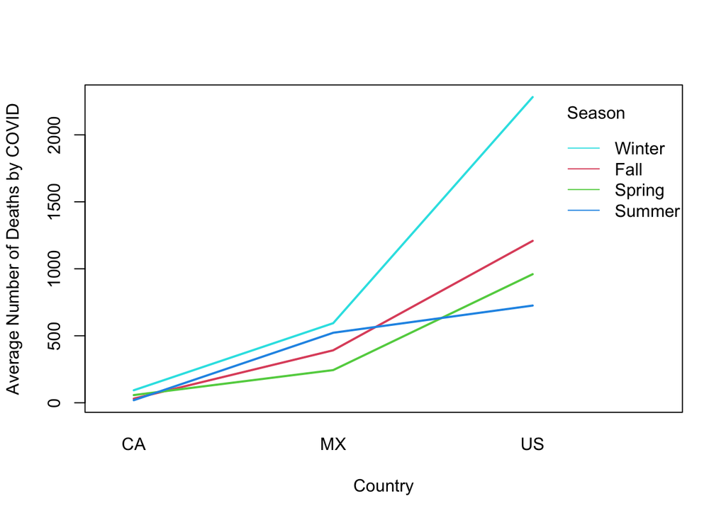

The differences in the heights of the four curves reflects the seasonal effects on deaths, and the deviation from horizontal reflects the effects of nationality on deaths. The plot indicates that there may be effects from nationality and season present in the number deaths caused by COVID. The curves for Winter, Fall, and Spring appear to have similar behaviors look to be nearly parallel. However, one may notice that the curves for for Fall, Spring, and Summer appear to intersect on the left portion of the plot. Also, the curve for Summer intersects with both the curves of Fall and Spring in between Mexico and US. This observation points out that there may be an Nationality-Seasonal interaction effect on the number of deaths.

# Model Proposal

To determine whether the nations in North America and the seasons in a calendar year have major effects on the number of deaths caused by COVID-19, we will be using a balanced Two-Way ANOVA model. A balanced Two-Way ANOVA model in factor-effect is written in the following form:
$$Y_{ijk} = \mu + \alpha_i + \beta_j + (\alpha \beta)_{ij} +
\epsilon_{ijk},
\ i = 1, \dots, a; \ \
j = 1, \ldots, b; \ \ k = 1, \ldots, n_{ij}.$$
where, $\alpha_i$ is the fixed main effect of factor A at the $i$th level, $\beta_j$ is the fixed main effect of factor B at the $j$th level, and $(\alpha \beta)_{ij}$ is the interaction effect when factor A is at the $i$th level and factor B is at the $j$th level. For this model to be valid, it must have the following constraints:
$$\sum_{i=1}^a \alpha_i = 0, \ \ \ \ \sum_{j=1}^b \beta_j = 0,$$
$$\sum_{i=1}^a (\alpha \beta)_{ij} = 0 \ \ \ \text{and} \ \ \
\sum_{j=1}^b (\alpha \beta)_{ij} = 0$$
and it must meet the assumption that $\varepsilon_{ijk}$ are i.i.d. (independently and identically distributed) as $N(0,\sigma^2)$.

A Two-Way Anova model is balance if the number of observation by two categories are equal. The following table displays the number of observations by season and nationality.

```
##
##      Fall Spring Summer Winter
##   CA  182    184    184    180
##   MX  182    184    184    180
##   US  182    184    184    180
```

Notice that these number are slightly different. This is because both Spring and Summer consist of two months with 31 days and one month with 30 days. The number of observations are smallest for Winter since it contains the month of February, which has the shortest number of days compared to all other months. Since the observations are large and do not differ much in size, we can say the a Two-Way ANOVA model applied to this data would be approximately balanced.

I believe that this model is appropriate for my task on studying the effects nationality and season have on the COVID death numbers since Two-Way ANOVA models give flexibility when the studying a quantitative variable using two categorical variables. Moreover, Two-Way ANOVA provides the ability to test whether main effects of each of the two categorical variables are present in the quantitative variable. Using a Two-Way ANOVA model for my question of interest, we will have the following representations:

- $Y_{ijk}$ is the cube-rooted number of deaths caused by COVID in the $i$th nation during the $j$th season.
- $\alpha_i$ is the main factor effect of nationality at the $i$th nation for $i = 1,\ldots,a=3$ (three nations),
- $\beta_j$ is the main effect of seasonality at the $j$th season for $j = 1, \ldots, b=4$ (four seasons),
- $(\alpha \beta)_{ij}$ is the interaction effect when of the $i$th nation and $j$th season.

# Model Fitting

Fitting a Two-Way ANOVA model using the cube-rooted number of COVID deaths, nationality and Season, we obtain the following results:

```
##                       Df Sum Sq Mean Sq F value Pr(>F)
## Country_code           2  17768    8884 2480.97 <2e-16 ***
## Season                 3   1842     614  171.49 <2e-16 ***
## Country_code:Season    6   1157     193   53.86 <2e-16 ***
## Residuals           2178   7799       4
## ---
## Signif. codes:  0 '***' 0.001 '**' 0.01 '*' 0.05 '.' 0.1 ' ' 1
```

Note that the Country_code, Season, and the interaction between Country_Code and season have corresponding $P$-values less than $2\times 10^{-16}$, which are very small $P$-values. This indicates that there is sufficient evidence to conclude that there are main effects from Nationality, main effects from Season, and interaction effects present in the cube-rooted number of deaths caused by COVID.

# Model Diagnostics

I will now explore plots involving the residuals from the Two-Way ANOVA to see whether the model assumption that $\varepsilon_{ijk}$ are i.i.d as $N(0,\sigma^2)$.

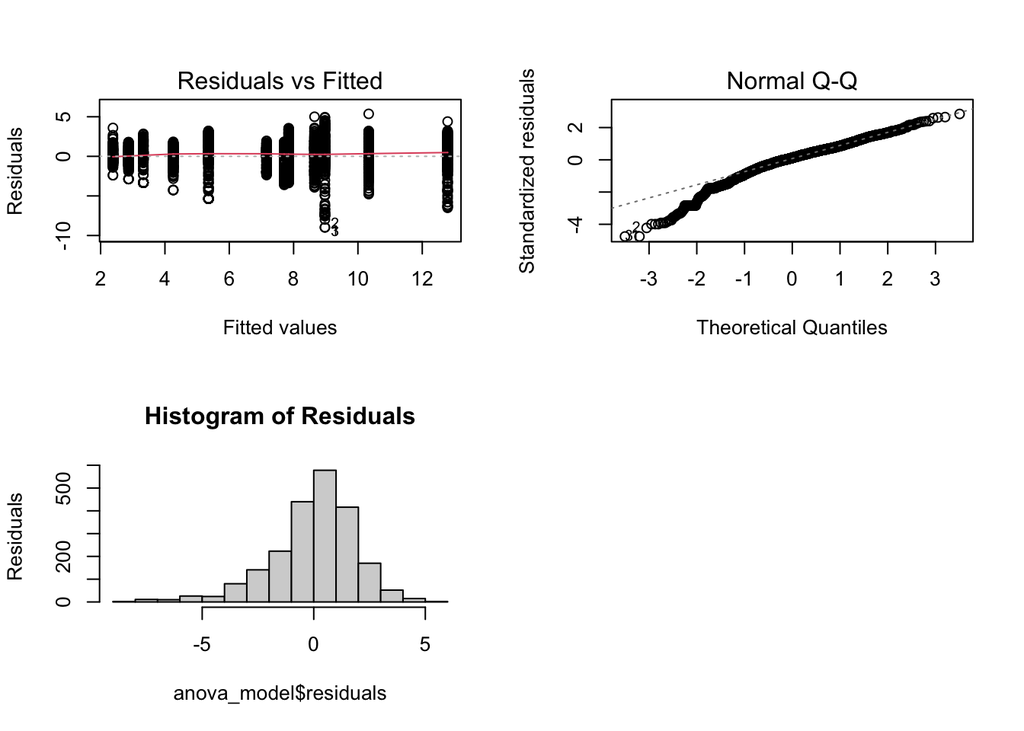

Viewing the Residuals vs Fitted plot, one can see that variability among the residuals are not necessarily the same. Furthermore, the red-line in this plot deviates slightly from the dash-line. This indicates that the error terms do not necessarily have constance variance and mean 0. Looking at the Normal Q-Q plot, it appears that most of the points are on the gray dashed line. However, one can see that the points on the left deviate from the dashed-line. This indications that the distribution of the residuals is slightly left-skewed. The histogram of the residuals shows that the distribution of the residual is slight left-skewed and looks to be almost symmetric. Since the Two-Way ANOVA model that was fitted is approximately balanced, the results obtained from the model fitting are pretty robust against the normality assumption and unequal variance.

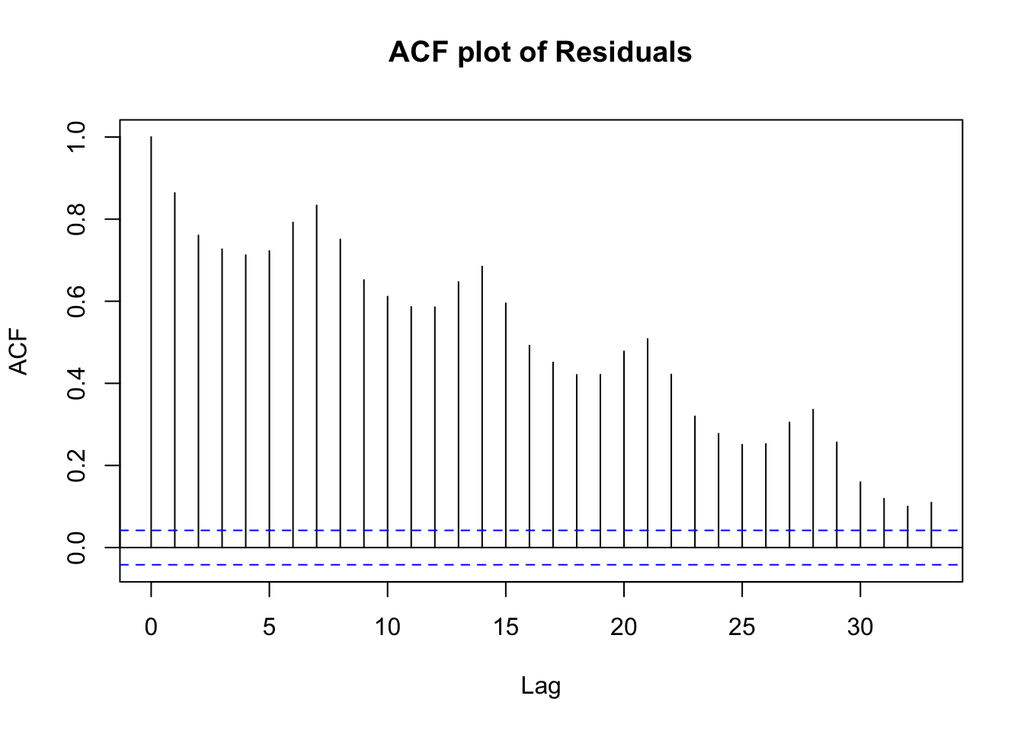

# Discussion and Conclusion

Although it appears that model assumptions for the Two-Way ANOVA model that I fit weren’t necessarily, the results obtained from the fitting process are robust again most of these assumptions since the model is approximately balanced. Since the data im working with is time series data and observational data, thus making it difficult to correct for non-independence of the residuals. Although, the model give supporting evidence that season has effects in the number of COVID deaths per day, there maybe be other factors along with season that may cause the number of deaths to fluctuate. In the future, I would like to learn whether there are other variables play a role in these numbers. Indeed, each season of the year bring various challenges to these nations, such as cooler and warmer temperatures and flu season, that may potentially cause the COVID death numbers for these three nations to go up. # References

Kutner, M. H., Nachtsheim, C. J., Neter, J., & Li, W. (2005). Applied Linear Statistical Models / Michael H. Kutner … et al.. McGraw-Hill Irwin.

“Coronavirus Disease (COVID-19) Situation Reports.” World Health Organization, World Health Organization, https://www.who.int/emergencies/diseases/novel-coronavirus-2019/situation-reports.

# Appendix - R Code used

```r
knitr::opts_chunk$set(echo = TRUE)
library(lubridate)
library(gplots)
library(car)
library(MASS)
library(tidyverse)
covid <- read.csv("https://covid19.who.int/WHO-COVID-19-global-data.csv")
#Shortening data to US, CA, and MX
US <- which(covid$Country_code=="US")
CA <- which(covid$Country_code=="CA")
MX <- which(covid$Country_code=="MX")

covid_NA <- covid[c(US,CA,MX),]
#Creating Month and Year variables
covid_NA$Month <- month(covid_NA$Date_reported)
covid_NA$Year <- year(covid_NA$Date_reported)

Jan2020 <- which(covid_NA$Month==1 & covid_NA$Year==2020)
Feb2020 <- which(covid_NA$Month==2 & covid_NA$Year==2020)

covid_NA <- covid_NA[-c(Jan2020,Feb2020),]

#Creating Season variable
covid_NA$Season <- c()
n_T <- nrow(covid_NA)

for (i in 1:n_T) {
  if (covid_NA$Month[i] == 1 | covid_NA$Month[i] == 2 | covid_NA$Month[i] == 12){
    covid_NA$Season[i] <- "Winter"
  }
  if (covid_NA$Month[i] == 3 | covid_NA$Month[i] == 4 | covid_NA$Month[i] == 5){
    covid_NA$Season[i] <- "Spring"
  }
  if (covid_NA$Month[i] == 6 | covid_NA$Month[i] == 7 | covid_NA$Month[i] == 8){
    covid_NA$Season[i] <- "Summer"
  }
  if (covid_NA$Month[i] == 9 | covid_NA$Month[i] == 10 | covid_NA$Month[i] == 11){
    covid_NA$Season[i] <- "Fall"
  }
}
covid_NA$Season <- as.factor(covid_NA$Season)
covid_NA$Country_code <- as.factor(covid_NA$Country_code)

covid_NA <- covid_NA[,-3]

# Removing all dates of March 2022 and beyond
March_2022 <- which(covid_NA$Month >= 3 & covid_NA$Year == 2022)
covid_NA <- covid_NA[-March_2022,]

rownames(covid_NA) <- 1:nrow(covid_NA)

#Creating Case Fatality Ratio Variable
covid_NA$New_CFR <- c()
for (i in 1:nrow(covid_NA)) {
  if(covid_NA$New_cases[i] == 0 ){
    covid_NA$New_CFR[i] = 0
  }
  else{
    covid_NA$New_CFR[i] <- covid_NA$New_deaths[i]/covid_NA$New_cases[i]
  }
}
#View(covid_NA)
US_NA <- which(covid_NA$Country_code=="US")
CA_NA <- which(covid_NA$Country_code=="CA")
MX_NA <- which(covid_NA$Country_code=="MX")

t <- 1:length(covid_NA$New_deaths[US_NA])

par(mfrow=c(2,2))
plot(t,covid_NA$New_deaths[US_NA],type='l', main="Number of Deaths due to
     COVID-19", xlab="Time: March 1, 2020 - February 28, 2022", ylab="Number of Deaths")
lines(t,covid_NA$New_deaths[CA_NA],type='l',col=3)
lines(t,covid_NA$New_deaths[MX_NA],type='l',col=4)
legend("topleft", legend = c("US","CA","MX"), lty=c(1,1,1), col=c(1,3,4),
       cex=0.5)

plot(t,covid_NA$New_cases[US_NA],type='l', main="Number of Cases due to
     COVID-19", xlab="Time: March 1, 2020 - February 28, 2022", ylab="Number of Deaths")
lines(t,covid_NA$New_cases[CA_NA],type='l',col=3)
lines(t,covid_NA$New_cases[MX_NA],type='l',col=4)
legend("topleft", legend = c("US","CA","MX"), lty=c(1,1,1), col=c(1,3,4),
       cex=0.5)
#par(mfrow=c(1,1))

plot(t,covid_NA$New_CFR[US_NA],type='l', main="Case Fatality Rate due to
     COVID-19", xlab="Time: March 1, 2020 - February 28, 2022", ylab="Case
     Fatality Rate",ylim=c(0,.5))
lines(t,covid_NA$New_CFR[CA_NA],type='l',col=3)
lines(t,covid_NA$New_CFR[MX_NA],type='l',col=4)
legend("topright", legend = c("US","CA","MX"), lty=c(1,1,1), col=c(1,3,4),
       cex=0.5)
par(mfrow=c(1,1))
#aggregate(New_deaths~Country_code+Season,data=covid_NA,mean)
aggregate(list(Deaths=covid_NA$New_deaths,Cases=covid_NA$New_cases,
               CFR = covid_NA$New_CFR),
          by=list(Country=covid_NA$Country_code,Season=covid_NA$Season), mean)
covid_NA %>%
  group_by(Country_code,Season) %>%
  summarise(min = fivenum(New_deaths)[1],
            Q1 = fivenum(New_deaths)[2],
            median = fivenum(New_deaths)[3],
            Q3 = fivenum(New_deaths)[4],
            max = fivenum(New_deaths)[5])
covid_NA %>%
  group_by(Country_code,Season) %>%
  summarise(min = fivenum(New_cases)[1],
            Q1 = fivenum(New_cases)[2],
            median = fivenum(New_cases)[3],
            Q3 = fivenum(New_cases)[4],
            max = fivenum(New_cases)[5])
covid_NA %>%
  group_by(Country_code,Season) %>%
  summarise(min = round(fivenum(New_CFR)[1],4),
            Q1 = round(fivenum(New_CFR)[2],4),
            median = round(fivenum(New_CFR)[3],4),
            Q3 = round(fivenum(New_CFR)[4],4),
            max = round(fivenum(New_CFR)[5],4))
interaction.plot(covid_NA$Country_code,covid_NA$Season,covid_NA$New_deaths,
          xlab="Country", ylab="Average Number of Deaths by COVID",type="l",
          lty=1, lwd=2, legend=T,col=c(2,3,4,5),trace.label="Season" )
table(covid_NA$Country_code,covid_NA$Season)
anova_model <- aov(I(New_deaths)^(1/3)~Country_code*Season,data=covid_NA)
summary(anova_model)
par(mfrow=c(2,2))
plot(anova_model,which=c(1,2))
hist(anova_model$residuals,main="Histogram of Residuals",
     ylab="Residuals")
acf(anova_model$residuals,main="ACF plot of Residuals")
```

# Acknowledgements

- Used STA 232A notes for reference.